# PA 4: Military Spending

## Data Organization

We are interested in comparing the military expenditures of countries in Eastern Europe. Our desired plot looks something like this:

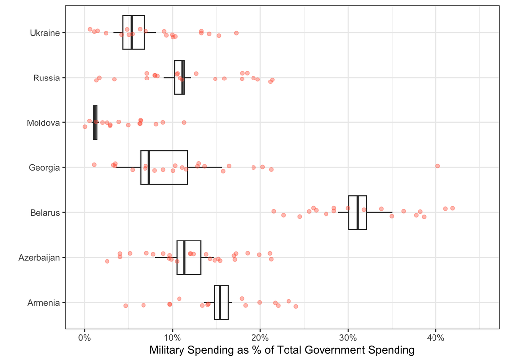

Unfortunately, if we want a point representing the spending for every country and year, we need every year to be a **single column**!

To tidy a dataset like this, we need to pivot the columns of years from wide format to long format. To do this process we need three arguments:

- `cols`: The set of columns that represent values, not variables. In these data, those are all the columns from `1988` to `2019`.
- `names_to`: The name of the variable that should be created to move these columns into. In these data, this could be `"Year"`.
- `values_to`: The name of the variable that should be created to move these column’s values into. In these data, this could be labeled `"Spending"`.

These form the three required arguments for the `pivot_longer()` function.

**6. Pivot the cleaned up `military` data set to a “longer” orientation. Save this new “long” version as a new object called `military_long`.**

Hint: **Do not** overwrite your cleaned up dataset!

## Data Visualization

Now that we’ve transformed the data, let’s create a plot to explore military spending across Eastern European countries.

**7. Create side-by-side boxplots to explore the military spending between Eastern European countries.**

Hint 1: Place the `Country` variable on an axis that makes it easier to read the labels!

Hint 2: Make sure you change the plot title and axis labels to accurately represent the plot.

Hint 3: Make sure you change the plot title and axis labels to accurately represent the plot.

```r
# Countries to include in the plot!
eastern_europe <- c("Armenia",
                    "Azerbaijan",
                    "Belarus",
                    "Georgia",
                    "Moldova",
                    "Russia",
                    "Ukraine")
```